# Clase 3 - Introducción a Python

```python
#Configuraciones de Python
import pandas as pd
pd.options.display.max_rows = 10
```

[figure not shown]

```python
from IPython.display import Image
Image(filename='./logo_python.png')
```

## Clases

En la primera clase mencionamos que:

Una clase es la definición de un nuevo tipo de objeto, una clase define las características (**atributos**) y el comportamiento (**métodos**) que mejor describen a un objeto de la vida real o de un sistema informático. También define la manera como se crea el objeto.

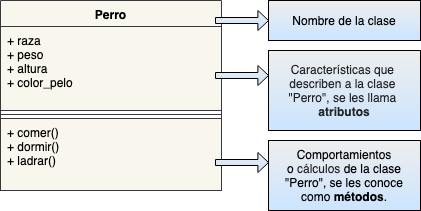

```python
from IPython.display import Image
Image(filename='./clase.png')
```

Una analogía muy sencilla es la de un plano arquitectónico para construir una casa, ya que podríamos ver a la clase como el plano arquitectónico y a la casa como el objeto.

Para crear una clase vamos a usar `class` de la siguiente forma:

**class** nombre_clase:

< cuerpo de la clase >

### Clase Vacía

```python
class Punto:
    pass
```

**Nota:** `pass` se usa para indicar que aún no se ha escrito código.

Para crear un objeto de tipo `Punto` usamos `()`

```python
p1 = Punto()
p1
```

```
<__main__.Punto at 0x11259bc18>
```

### Atributos

Los objetos en python son muy maleables, tanto así que podemos crear nuevos atributos de una clase después de instanciar el objeto.

```python
p1 = Punto()
p2 = Punto()

p1.x = 5
p1.y = 4
p2.x = 3
p2.y = 6

print(p1.x, p1.y)
print(p2.x, p2.y)
```

```
5 4
3 6
```

Como se puede observar podemos agregar atributos al objeto, pero esta no es la forma correcta de agregar los atributos a la clase, ya que lo ideal es que estos atributos se creen con el objeto.

```python
p3 = Punto()
print(p3.x, p3.y)
```

```
---------------------------------------------------------------------------
AttributeError                            Traceback (most recent call last)
<ipython-input-8-e6db1304044e> in <module>
      1 p3 = Punto()
----> 2 print(p3.x, p3.y)

AttributeError: 'Punto' object has no attribute 'x'
```

Cuando hacemos `Punto()` creamos una instancia de la clase `Punto` (creamos un objeto en memoria de tipo `Punto`). Pero cuando hacemos `Punto()` se llama a un método llamado `__init__` el cual se encarga de inicializar el objeto, es en esta función donde se tienen que crear los atributos de la clase.

Para definir un método dentro de la clase se usa `def` para crear funciones dentro de `class`.

```python
class Punto:
    def __init__(self, x = 0, y = 0):
        self.x = x
        self.y = y
```

```python
p3 = Punto(5, 10)
print(p3.x, p3.y)
```

```
5 10
```

`self` es una variable que que se refiere al objeto `Punto` que está llamando al método. `self` nos ayuda a distinguir qué variables son de la clase (**atributos**) y cuales son variables del método.

### Métodos

`__init__` es un nombre reservado para el constructor de la clase, pero podemos hacer nuestras propias funciones. Las funciones que hagamos serán los métodos de la clase y por lo general hacen algún tipo de cálculo o tarea.

```python
class Punto:
    def __init__(self): # Constructor
        self.x = 0
        self.y = 0
    def resetear(self):
        self.x = 0
        self.y = 0
```

```python
p = Punto()
p.x = 5
p.y = 4
print(p.x, p.y)
```

```
5 4
```

```python
p.resetear()
print(p.x, p.y)
```

```
0 0
```

Veamos cómo se vería esta clase un poco más completa:

- __init__ : El constructor de la clase
- cambiar: Un método que permite cambiar los valores de los atributos
- calcular_distancia: Un método que permite calcular la distancia con otro objeto de tipo Punto
- __str__: Un método reservado que se llama cuando llamamos a la función `str`, este método tiene que devolver un string.

```python
import math

class Punto:
    def __init__(self, x = 0, y = 0): # Constructor
        self.x = x
        self.y = y
    def cambiar(self, x, y):
        self.x = x
        self.y = y
    def calcular_distancia(self, otro_Punto):
        return math.sqrt((self.x - otro_Punto.x)**2 +
                         (self.y - otro_Punto.y)**2)
    def __str__(self):
        return "Punto: (%i, %i)" % (self.x,self.y)
```

```python
Punto1 = Punto(2,3)
Punto2 = Punto(-2,9)
```

```python
print(Punto1)
```

```
Punto: (2, 3)
```

```python
print(Punto2)
```

```
Punto: (-2, 9)
```

```python
Punto2.calcular_distancia(Punto1)
```

```
7.211102550927978
```

```python
Punto1.cambiar(3, 4)
Punto2.calcular_distancia(Punto1)
```

```
7.0710678118654755
```

Otro ejemplo del comportamiento de una clase es:

```python
class Perro():
    def __init__(self, nombre, edad):
        self.nombre = nombre
        self.edad = edad
    def sentarse(self):
        print(self.nombre.title() + " está ahora sentado.")
    def levantarse(self):
        print(self.nombre.title() + " se levantó!")
    def __str__(self):
        return "%s [%i]" % (self.nombre, self.edad)
```

```python
mi_Perro = Perro('Puppy', 14)
su_Perro = Perro('Negro', 3)
```

```python
print("El nombre de mi perro es " + mi_Perro.nombre.title() + ".")
```

```
El nombre de mi perro es Puppy.
```

```python
print("Mi perro tiene " + str(mi_Perro.edad) + " de edad.")
```

```
Mi perro tiene 14 de edad.
```

```python
mi_Perro.sentarse()
```

```
Puppy está ahora sentado.
```

```python
print("El nombre de su perro es " + su_Perro.nombre.title() + ".")
```

```
El nombre de su perro es Negro.
```

```python
print("Su perro tiene " + str(su_Perro.edad) + " de edad.")
```

```
Su perro tiene 3 de edad.
```

```python
su_Perro.sentarse()
```

```
Negro está ahora sentado.
```

```python
mi_Perro.levantarse()
```

```
Puppy se levantó!
```

```python
su_Perro.levantarse()
```

```
Negro se levantó!
```

## Tipos de Atributos

### Atributos Públicos

Los atributos públicos son aquellos atributos que pueden ser accedidos directamente.

```python
class Punto:
    def __init__(self, x = 0, y = 0):
        self.x = x
        self.y = y
```

```python
Z = Punto(3, 6)
```

Podemos acceder fácilmente a `x` y `y` desde fuera de la clase.

```python
Z.x
```

```
3
```

```python
Z.y
```

```
6
```

También podemos cambiar los valores de `x` y `y` desde fuera de la clase.

```python
Z.x = 5
Z.x
```

```
5
```

```python
Z.y = 10
Z.y
```

```
10
```

### Atributos Privados

Los atributos privados no permiten el acceso desde fuera de la clase, lo cual resulta muy útil cuando poseemos atributos importantes para el correcto funcionamiento de la clase.

Los atributos privados se definen con un doble guión bajo antes del nombre (NO puede terminar con doble guión bajo):

```python
class Juego:
    def __init__(self, cantidad_jugadores, tiempo_partida):
        self.cantidad_jugadores = cantidad_jugadores
        self.tiempo_partida = tiempo_partida
        self.__rondas_jugadas = 0
```

```python
partida = Juego(2, 60)
partida.cantidad_jugadores
```

```
2
```

```python
partida.tiempo_partida
```

```
60
```

```python
partida.__rondas_jugadas__
```

```
---------------------------------------------------------------------------
AttributeError                            Traceback (most recent call last)
<ipython-input-39-c49776b7f26d> in <module>
----> 1 partida.__rondas_jugadas__

AttributeError: 'Juego' object has no attribute '__rondas_jugadas__'
```

```python
partida.rondas_jugadas
```

```
---------------------------------------------------------------------------
AttributeError                            Traceback (most recent call last)
<ipython-input-40-0a698a0837f8> in <module>
----> 1 partida.rondas_jugadas

AttributeError: 'Juego' object has no attribute 'rondas_jugadas'
```

**Nota**: En python a diferencia de otros lenguajes de programación, el concepto de atributo privado no estrictamente correcto ya que lo que pasa se denomina "name mangling" y solo dificulta el acceso directo a los atributos.

También se puede usar son solo guión bajo para indicar que este atributo debería de ser manipulado solo en subclases y no es recomendable su manipulación por fuera de la clase.

Los atributos con un solo guión bajo no son diferentes los atributos públicos, solo que se entiende que no se debería de manipular a la ligera.

## Tipos de Métodos

### Métodos Públicos

Los métodos públicos son aquellos métodos que pueden ser accedidos directamente.

```python
import math

class Punto:
    def __init__(self, x = 0, y = 0): # Constructor
        self.x = x
        self.y = y
    def cambiar(self, x, y):
        self.x = x
        self.y = y
    def calcular_distancia(self, otro_Punto):
        return math.sqrt((self.x - otro_Punto.x)**2 +
                         (self.y - otro_Punto.y)**2)
    def __str__(self):
        return "Punto: (%i, %i)" % (self.x,self.y)
```

```python
A = Punto(5, 6)
B = Punto(5, 16)
```

```python
A.calcular_distancia(B)
```

```
10.0
```

```python
str(A)
```

```
'Punto: (5, 6)'
```

```python
A.__str__()
```

```
'Punto: (5, 6)'
```

### Métodos Privados

Los métodos privados no permiten el acceso desde fuera de la clase, lo cual resulta muy útil cuando poseemos métodos que solo son útiles para el manejo de la lógica del objeto.

Al igual que con los atributos privados, los métodos privados se definen con un doble guión bajo antes del nombre (NO puede terminar con doble guión bajo):

```python
import math

class Secuencias:
    def __init__(self):
        pass
    def fibonacci_iterativo(self, n):
        resultado = [1, 1]
        for indice in range(n-2):
            resultado.append(resultado[indice] + resultado[indice + 1])
        return resultado
    def __formula_fibo(self, n):
        return (1/math.sqrt(5)) * ( ((1 + math.sqrt(5)) / 2) ** (n + 1) - ((1 - math.sqrt(5)) / 2) ** (n + 1)  )
    def fibonacci_formula(self, n):
        resultado = []
        for indice in range(n):
            resultado.append(int(self.__formula_fibo(indice)))
        return resultado
```

```python
x = Secuencias()
x.fibonacci_iterativo(15)
```

```
[1, 1, 2, 3, 5, 8, 13, 21, 34, 55, 89, 144, 233, 377, 610]
```

```python
x.fibonacci_formula(15)
```

```
[1, 1, 2, 3, 5, 8, 13, 21, 34, 55, 89, 144, 233, 377, 610]
```

```python
x.__formula_fibo(10)
```

```
---------------------------------------------------------------------------
AttributeError                            Traceback (most recent call last)
<ipython-input-49-38d08641f647> in <module>
----> 1 x.__formula_fibo(10)

AttributeError: 'Secuencias' object has no attribute '__formula_fibo'
```

## Herencia

La herencia es una de las características más notorias de la programación orientada a objetos.

La herencia nos permite heredar características (atributos) y funcionalidades (Métodos) entre clases. Esta práctica nos permite reutilizar nuestro código y generalizar comportamientos.

Para realizar un herencia simple se ocupa una clases base (clase padre) y la clase derivada (clase hija).

### Clase Base

La clase base es la clase general que provee de atributos y métodos a las clases más específicas.

Para crear una clase base no hay que hacer nada especial, simplemente crear una clase común y corriente como las vistas hasta el momento.

```python
class Carro:
    def __init__(self, fabricante, modelo, anno):
        self.fabricante = fabricante
        self.modelo = modelo
        self.anno = anno
        self.kilometraje = 0
    def obtener_nombre_completo(self):
        nombre_completo = self.fabricante + ' ' + str(self.anno) + ' ' + self.modelo
        return nombre_completo.title()
    def lee_kilometraje(self):
        print("Este carro tiene " + str(self.kilometraje) + " kilometros recorridos.")
    def modifica_kilometraje(self, kilometros):
        if kilometros >= self.kilometraje:
            self.kilometraje = kilometros
        else:
            print("Usted no puede modificar para atrás el kilometraje!")
    def incrementa_kilometraje(self, kilometros):
        self.kilometraje += kilometros
```

### Clase Derivada

Las clase derivada es la clase que va a "recibir" todos los atributos y métodos de la clase base.

Para crear una clase derivada se tiene que hacer de las siguiente forma:

**class** nombre_clase (nombre_clase_base):

< cuerpo de la clase >

**Nota**: Cuando hacemos una clase normal sin heredar, python hereda automáticamente de `object`

```python
class Carro_Electrico(Carro):
    def __init__(self, fabricante, modelo, anno):
        super().__init__(fabricante, modelo, anno)
        self.capacidad_bateria = 70
    def describe_bateria(self):
        return "Este carro tiene una bateria de capacidad " + str(self.capacidad_bateria) + "-kWh."
```

```python
mi_tesla = Carro_Electrico('tesla', 'modelo S', 2018)
mi_tesla.obtener_nombre_completo()
```

```
'Tesla 2018 Modelo S'
```

```python
mi_tesla.describe_bateria()
```

```
'Este carro tiene una bateria de capacidad 70-kWh.'
```

**Nota**: `super()` nos permite acceder a la clase base desde la clase derivada, en este caso `super().__init__` nos permite llamar al constructor de la clase base.

### Sobrescritura de Métodos

Es un método que se encuentra en la clase base y en la clase derivada con el mismo nombre, provocando que los objetos de la clase derivada use solamente la que está definió y no la que la clase base implemento.

Para usar ambas funciones podemos usar `super()`.

```python
class Carro:
    def __init__(self, fabricante, modelo, anno):
        self.fabricante = fabricante
        self.modelo = modelo
        self.anno = anno
        self.kilometraje = 0
    def obtener_nombre_completo(self):
        nombre_completo = self.fabricante + ' ' + str(self.anno) + ' ' + self.modelo
        return nombre_completo.title()
    def lee_kilometraje(self):
        return "Este carro tiene " + str(self.kilometraje) + " kilometros recorridos."
    def modifica_kilometraje(self, kilometros):
        if kilometros >= self.kilometraje:
            self.kilometraje = kilometros
        else:
            print("Usted no puede modificar para atrás el kilometraje!")
    def incrementa_kilometraje(self, kilometros):
        self.kilometraje += kilometros
    def __str__(self):
        resp = self.obtener_nombre_completo()
        resp = resp + "\n" + self.lee_kilometraje()
        return resp
```

```python
class Carro_Electrico(Carro):
    def __init__(self, fabricante, modelo, anno):
        super().__init__(fabricante, modelo, anno)
        self.capacidad_bateria = 70
    def describe_bateria(self):
        return "Este carro tiene una bateria de capacidad " + str(self.capacidad_bateria) + "-kWh."
    def __str__(self):
        resp = super().__str__() + "\n" + self.describe_bateria()
        return resp
```

```python
mi_tesla = Carro_Electrico('tesla', 'modelo S', 2018)
print(mi_tesla)
```

```
Tesla 2018 Modelo S
Este carro tiene 0 kilometros recorridos.
Este carro tiene una bateria de capacidad 70-kWh.
```

En este caso tanto `__str__` como `__init__` son métodos que `Carro_Electrico` sobrescribe de `Carro`

## Herencia Múltiple

Como lo hemos visto hasta el momento la herencia nos permite mantener los atributos y métodos de una clase base en otras clases hijas.

Pero python soporta la herencia múltiple permitiéndonos que una clase hija herede de dos o más clases al mismo tiempo.

```python
class Persona:
    def __init__(self, nombre, edad, sexo):
        self.__nombre = nombre
        self.__edad = edad
        self.__sexo = sexo
    def __str__(self):
        x = f"Nombre:{self.__nombre} Edad: {self.__edad} Sexo: {self.__sexo}"
        return(x)

class Profesor(Persona):
    def __init__(self, nombre, edad, sexo, escuela, salario):
        Persona.__init__(self, nombre, edad, sexo)
        self.__escuela = escuela
        self.__salario = salario
    def __str__(self):
        x = f"{Persona.__str__(self)}\nEscuela: {self.__escuela} Salario: {self.__salario}"
        return(x)

class Investigador(Persona):
    def __init__(self, nombre, edad, sexo, proyecto):
        Persona.__init__(self, nombre, edad, sexo)
        self.__proyecto = proyecto
    @property
    def proyecto(self):
        return(self.__proyecto)
    def __str__(self):
        x = f"{Persona.__str__(self)}\nProyecto: {self.__proyecto}"
        return(x)

class ProfesorUniversitario(Profesor, Investigador):
    def __init__(self, nombre, edad, sexo, escuela, salario, proyecto):
        # No podemos usar super ya que no hay dos clases bases
        Investigador.__init__(self, nombre, edad, sexo, proyecto)
        Profesor.__init__(self, nombre, edad, sexo, escuela, salario)
    def __str__(self):
        x = f"{Profesor.__str__(self)}\nProyecto: {self.proyecto}"
        return(x)
```

```python
x = ProfesorUniversitario("Pablo", 50, "M", "Biologia", 500000, "Celulas Madre")
print(x)
```

```
Nombre:Pablo Edad: 50 Sexo: M
Escuela: Biologia Salario: 500000
Proyecto: Celulas Madre
```

## Componente-Compuesto

**Relaciones Componente-Compuesto**

```python
class Bateria():
    def __init__(self, capacidad = 70, marca = "LTH"):
        self.capacidad = capacidad
        self.marca = marca
    def describe(self):
        print("Este carro tiene una batería marca " + self.marca + " de capacidad " + str(self.capacidad) + "-kWh.")
```

```python
mi_bateria = Bateria(90, "Hitachi")
mi_bateria.describe()
```

```
Este carro tiene una batería marca Hitachi de capacidad 90-kWh.
```

### Clase Base

```python
class Carro():
    def __init__(self, fabricante, modelo, anno):
        self.fabricante = fabricante
        self.modelo = modelo
        self.anno = anno
        self.kilometraje = 0
    def obtener_nombre_completo(self):
        nombre_completo = self.fabricante + ' ' + str(self.anno) + ' ' + self.modelo
        return nombre_completo.title()
    def lee_kilometraje(self):
        print("Este carro tiene " + str(self.kilometraje) + " kilometros recorridos.")
    def modifica_kilometraje(self, kilometros):
        if kilometros >= self.kilometraje:
            self.kilometraje = kilometros
        else:
            print("Usted no puede modificar para atrás el kilometraje!")
    def incrementa_kilometraje(self, kilometros):
        self.kilometraje += kilometros
```

### Clase derivada

```python
class Carro_Electrico(Carro):
    def __init__(self, fabricante, modelo, anno, capacidad_bateria, marca_bateria):
        super().__init__(fabricante, modelo, anno)
        self.bateria = Bateria(capacidad_bateria, marca_bateria)
```

```python
mi_tesla = Carro_Electrico('tesla', 'modelo S', 2018, 65, "Hitachi")
print(mi_tesla.obtener_nombre_completo())
```

```
Tesla 2018 Modelo S
```

```python
mi_tesla.bateria.describe()
```

```
Este carro tiene una batería marca Hitachi de capacidad 65-kWh.
```

## GETTERS AND SETTERS

Son los métodos obtener y modificar respectivamente para un atributo de una clase.

```python
class Prueba(object):
        def __init__(self):
            self.__dato = 1
        def obtener_dato(self):
            return self.__dato
        def modificar_dato(self,nuevo_dato):
            self.__dato = nuevo_dato
```

```python
tempo = Prueba()
tempo.obtener_dato()
tempo.modificar_dato(-3)
tempo.obtener_dato()
```

```
-3
```

**Nota**: Lo anterior funciona, pero no es Python, es C++ o JAVA, pero no estilo Python.

El acceso directo a los atributos es la forma natural en Python de hacer las cosas, por lo que cualquier solución para el acceso a los atributos mediado debe mantener esa interfaz pública. Hay algunas maneras de hacerlo, como anular __getattr__ y __setattr__, pero la mejor manera es usar atributos administrados con @property, como sigue:

```python
class Prueba(object):
        def __init__(self):
            self.__dato = 1
        def obtener_dato(self):
            print("Pasó por obtener")
            return self.__dato
        def modificar_dato(self,nuevo_dato):
            print("Pasó por modificar")
            self.__dato = nuevo_dato
        dato = property(obtener_dato,modificar_dato)
```

```python
tempo = Prueba()
tempo.obtener_dato()
```

```
Pasó por obtener
```

```
1
```

```python
tempo.modificar_dato(-3)
```

```
Pasó por modificar
```

```python
tempo.obtener_dato()
```

```
Pasó por obtener
```

```
-3
```

La instrucción dato = property(obtener_dato,modificar_dato) hace que Python conozca que los métodos obtener_dato() y modificar_dato() son los get y set del atributo dato.

Todavía mejor de la siguiente manera:

```python
class Prueba(object):
        def __init__(self):
            self.__dato = 1
        @property
        def dato(self):
            print("Pasó por obtener")
            return self.__dato
        @dato.setter
        def dato(self, nuevo_dato):
            print("Pasó por modificar")
            if nuevo_dato > 100:
                raise ValueError("El dato debe ser menor o igual a 100")
            self.__dato = nuevo_dato
```

```python
tempo = Prueba()
print(tempo.dato)
```

```
Pasó por obtener
1
```

```python
tempo.dato = 3
```

```
Pasó por modificar
```

```python
print(tempo.dato)
```

```
Pasó por obtener
3
```

```python
tempo.dato = 200 # Da error controlado
```

```
Pasó por modificar
```

```
---------------------------------------------------------------------------
ValueError                                Traceback (most recent call last)
<ipython-input-75-c55bfbb960ba> in <module>
----> 1 tempo.dato = 200 # Da error controlado

<ipython-input-71-413fba19b1ed> in dato(self, nuevo_dato)
     10             print("Pasó por modificar")
     11             if nuevo_dato > 100:
---> 12                 raise ValueError("El dato debe ser menor o igual a 100")
     13             self.__dato = nuevo_dato

ValueError: El dato debe ser menor o igual a 100
```

## Más sobre el uso de Python @property

**Clase para covertir Celsius a fahrenheit**

```python
class Celsius:
    def __init__(self, temperatura = 0):
        self.temperatura = temperatura
    def convierte_fahrenheit(self):
        return (self.temperatura * 1.8) + 32
```

```python
instancia = Celsius()
```

**set temperatura**

```python
instancia.temperatura = 37
```

**get temperatura**

```python
instancia.temperatura
```

```
37
```

**Convierte la temperatura**

```python
instancia.convierte_fahrenheit()
```

```
98.60000000000001
```

**Métodos Get (Obtener) y Set (Modificar) al estilo C++ o Java**

```python
class Celsius:
    def __init__(self, temperatura = 0):
        self.modificar_temperatura(temperatura)
    def convierte_fahrenheit(self):
        return (self.obtener_temperatura() * 1.8) + 32
    def obtener_temperatura(self):
        return self._temperatura
    def modificar_temperatura(self, nuevo_valor):
        if nuevo_valor < -273:
            raise ValueError("Una temperatura por debajo de -273 no es posible")
        self._temperatura = nuevo_valor
```

```python
c = Celsius(-277)  # Da el error controlado
```

```
---------------------------------------------------------------------------
ValueError                                Traceback (most recent call last)
<ipython-input-82-5b4ee3d1b832> in <module>
----> 1 c = Celsius(-277)  # Da el error controlado

<ipython-input-81-f5a6e030036e> in __init__(self, temperatura)
      1 class Celsius:
      2     def __init__(self, temperatura = 0):
----> 3         self.modificar_temperatura(temperatura)
      4     def convierte_fahrenheit(self):
      5         return (self.obtener_temperatura() * 1.8) + 32

<ipython-input-81-f5a6e030036e> in modificar_temperatura(self, nuevo_valor)
      8     def modificar_temperatura(self, nuevo_valor):
      9         if nuevo_valor < -273:
---> 10             raise ValueError("Una temperatura por debajo de -273 no es posible")
     11         self._temperatura = nuevo_valor

ValueError: Una temperatura por debajo de -273 no es posible
```

```python
c = Celsius(37)
print(c.obtener_temperatura())
```

```
37
```

```python
c.modificar_temperatura(10)
print(c.obtener_temperatura())
```

```
10
```

**Versión Usando property al verdadero estilo Python**

```python
class Celsius:
    def __init__(self, temperatura = 0):
        self.__temperatura = temperatura
    def convierte_fahrenheit(self):
        return (self.temperatura * 1.8) + 32
    def obtener_temperatura(self):
        print("Obteniendo el valor")
        return self.__temperatura
    def modificar_temperatura(self, nuevo_valor):
        if nuevo_valor < -273:
            raise ValueError("Una temperatura por debajo de -273 no es posible")
        print("Modificando el valor")
        self.__temperatura = nuevo_valor
    temperatura = property(obtener_temperatura,modificar_temperatura)
```

Nota: Añadimos una función print() dentro de obtener_temperatura() y modificar_temperatura() para observar claramente que se están ejecutando. Esto no debe ir.

La última línea del código temperatura = property(obtener_temperatura,modificar_temperatura) hace el atributo temperatura una propiedad del objeto, es decir, la propiedad une el código de obtener_temperatura() y modificar_temperatura() al atributo temperatura.

Así cualquier código que recupere el valor de temperatura llamará automáticamente obtener_temperatura() en lugar del atributo en forma directa. Del mismo modo, cualquier código que asigna valor a la temperatura llamará automáticamente modificar_temperatura(). Esta es una característica muy propia de Python.

```python
c = Celsius()
c.temperatura
```

```
Obteniendo el valor
```

```
0
```

```python
c.temperatura = 37
```

```
Modificando el valor
```

```python
c.convierte_fahrenheit()
```

```
Obteniendo el valor
```

```
98.60000000000001
```

Una forma más transparente de hacer lo anterior y que permite usar el mismo nombre en el método que el del atributo es la siguiente:

```python
class Celsius:
    def __init__(self, temperatura = 0):
        self.__temperatura = temperatura
    def convierte_fahrenheit(self):
        return (self.temperatura * 1.8) + 32
    @property
    def temperatura(self):
        print("Obteniendo el valor")
        return self.__temperatura
    @temperatura.setter
    def temperatura(self, nuevo_valor):
        if nuevo_valor < -273:
            raise ValueError("Una temperatura por debajo de -273 no es posible")
        print("Retornando el valor")
        self.__temperatura = nuevo_valor
```

```python
c = Celsius()
c.temperatura
```

```
Obteniendo el valor
```

```
0
```

```python
c.temperatura = 37
```

```
Retornando el valor
```

```python
c.temperatura
```

```
Obteniendo el valor
```

```
37
```

```python
c.convierte_fahrenheit()
```

```
Obteniendo el valor
```

```
98.60000000000001
```

Otro ejemplo, puede ser mi propio Data Frame usando Componente-Compuesto

```python
import pandas as pd
import numpy as np

class mi_DF():
    def __init__(self, DF = pd.DataFrame()):
        self.__num_filas = DF.shape[0]
        self.__num_columnas = DF.shape[1]
        self.__DF = DF
    @property
    def num_filas(self):
        return self.__num_filas
    @property
    def num_columnas(self):
        return self.__num_columnas
    @property
    def DF(self):
        return self.__DF
    def maximo(self):
        max = self.DF.iloc[0,0]
        for i in range(self.num_filas):
            for j in range(self.num_columnas):
                if self.DF.iloc[i,j] > max:
                    max = self.DF.iloc[i,j]
        return max
    def valores(self):
        min = self.DF.iloc[0,0]
        max = self.DF.iloc[0,0]
        total_ceros = 0
        total_pares = 0
        for i in range(self.num_filas):
            for j in range(self.num_columnas):
                if self.DF.iloc[i,j] > max:
                    max = self.DF.iloc[i,j]
                if self.DF.iloc[i,j] < min:
                    min = self.DF.iloc[i,j]
                if self.DF.iloc[i,j] == 0:
                    total_ceros = total_ceros+1
                if self.DF.iloc[i,j] % 2 == 0:
                    total_pares = total_pares+1
        return {'Maximo' : max, 'Minimo' : min, 'Total_Ceros' : total_ceros, 'Pares' : total_pares}
    def estadisticas(self,nc):
        media = np.mean(self.DF.iloc[:,nc])
        mediana = np.median(self.DF.iloc[:,nc])
        deviacion = np.std(self.DF.iloc[:,nc])
        varianza = np.var(self.DF.iloc[:,nc])
        maximo = np.max(self.DF.iloc[:,nc])
        minimo = np.min(self.DF.iloc[:,nc])
        return {'Variable' : self.DF.columns.values[nc],
                'Media' : media,
                'Mediana' : mediana,
                'DesEst' : deviacion,
                'Varianza' : varianza,
                'Maximo' : maximo,
                'Minimo' : minimo}
```

```python
datos = mi_DF(pd.DataFrame([[4,1,-3],[2,4.4,0],[-5,9,198],[2,4,-5]]))
print(datos.num_filas)
```

```
4
```

```python
print(datos.num_columnas)
```

```
3
```

```python
print(datos.DF)
```

```
   0    1    2
0  4  1.0   -3
1  2  4.4    0
2 -5  9.0  198
3  2  4.0   -5
```

```python
print(datos.maximo())
```

```
198
```

```python
print(datos.valores())
```

```
{'Maximo': 198, 'Minimo': -5, 'Total_Ceros': 1, 'Pares': 6}
```

```python
print(datos.estadisticas(1))
```

```
{'Variable': 1, 'Media': 4.6, 'Mediana': 4.2, 'DesEst': 2.8600699292150185, 'Varianza': 8.18, 'Maximo': 9.0, 'Minimo': 1.0}
```

```python
datos_est = pd.read_csv('ejemplo_estudiantes.csv',delimiter=';',decimal=",",
                        index_col=0)
datos = mi_DF(datos_est)
```

```python
print(datos.num_filas)
```

```
10
```

```python
print(datos.num_columnas)
```

```
5
```

```python
print(datos.DF)
```

```
        Matematicas  Ciencias  Espanol  Historia  EdFisica
Lucia           7.0       6.5      9.2       8.6       8.0
Pedro           7.5       9.4      7.3       7.0       7.0
Ines            7.6       9.2      8.0       8.0       7.5
Luis            5.0       6.5      6.5       7.0       9.0
Andres          6.0       6.0      7.8       8.9       7.3
Ana             7.8       9.6      7.7       8.0       6.5
Carlos          6.3       6.4      8.2       9.0       7.2
Jose            7.9       9.7      7.5       8.0       6.0
Sonia           6.0       6.0      6.5       5.5       8.7
Maria           6.8       7.2      8.7       9.0       7.0
```

```python
print(datos.maximo())
```

```
9.7
```

```python
print(datos.valores())
```

```
{'Maximo': 9.7, 'Minimo': 5.0, 'Total_Ceros': 0, 'Pares': 10}
```

```python
print(datos.estadisticas(3))
```

```
{'Variable': 'Historia', 'Media': 7.9, 'Mediana': 8.0, 'DesEst': 1.0639548862616308, 'Varianza': 1.132, 'Maximo': 9.0, 'Minimo': 5.5}
```

[figure not shown]

```python
from IPython.display import Image
Image(filename='./logo_python.png')
```